# Lecture 9: Conjoint Analysis & WTP

What Do Customers Actually Value — and What Will They Pay?

## Every model serves a marketing decision

Win customers

CMO: “Which channels and touchpoints are actually bringing customers in?”

- L01A/B testingDid it work?
- L03Marketing mix modelingHow much?
- L06Multi-touch attributionHow much?

Set the offer

Head of pricing: “What should we charge, and which features matter?”

- L02Price elasticityHow much?
- L09Conjoint analysis · todayWhat do they want?

The marketing decisionStart from what the business is asking

Keep customers

Head of retention: “Who is leaving, when, and who should get the save offer?”

- L04Survival analysisWhat next?
- L05Markov chainsWhat next?
- L07Uplift modelingDid it work?

Value customers

CFO: “What is a customer worth to us?”

- L08Customer lifetime valueWhat next?

Plan ahead

Operations: “What will next quarter look like?”

- L10Demand forecastingWhat next?

**Question type:**Did it work? causal effectHow much? how much X moves YWhat do they want? preferencesWhat next? prediction

## Motivating Problem

**Tip**

**Setting:** A firm seeks to recover consumer preference parameters and willingness-to-pay from stated-choice data. You are considering a premium tier: it has no ads and includes exclusive content. How much more will customers actually pay for each feature? And if you add a third option, how does it affect existing product shares?

**Learning Objectives**

- Estimate WTP for each product feature from conjoint data
- Run a market simulation using the softmax choice model
- Apply the IIA property (and know when it fails)
- Describe how a choice experiment is designed and fielded
- Find the profit-maximizing price and compare feature bundles by profit

## What Conjoint Measures

Stated-preference methods recover latent attribute valuations from discrete choice behaviour. Respondents reveal preferences through forced choices rather than direct self-report, mitigating hypothetical bias.

**Experimental design:** Each respondent evaluates paired alternatives differing on price and attributes. Randomization of attribute levels across respondents identifies each coefficient.

| Option A | Option B |
| --- | --- |
| $10/month | $16/month |
| Ad-supported | No ads |
| Standard content | Premium content |

Repeat across many pairs → MNL regression extracts implicit attribute weights.

## Running a Choice Experiment

1. **Attributes and levels.** HW09: price $10 / $14 / $18 / $22 · content · ads · plan. Keep prices inside the range you would charge.
2. **Survey size.** HW09: 400 respondents × 8 tasks × 3 profiles = 9,600 rows.
3. **Random levels.** Draw each attribute’s level independently for every profile, and redraw a task that shows two identical profiles. Price is then uncorrelated with the features.
4. **“None of these”?** Needed to price a whole product line: it lets the model observe customers leaving the market.
5. **Field and save in long format.** Qualtrics, Sawtooth or Conjointly build and field the tasks. One row per profile shown, `chosen` = 1 for the pick.

No package needed: a random design is a few lines of pandas (code in the notes, Section 1.3). In the HW09 data, every standard error is under a tenth of its coefficient.

## From the Survey Screen to the Data

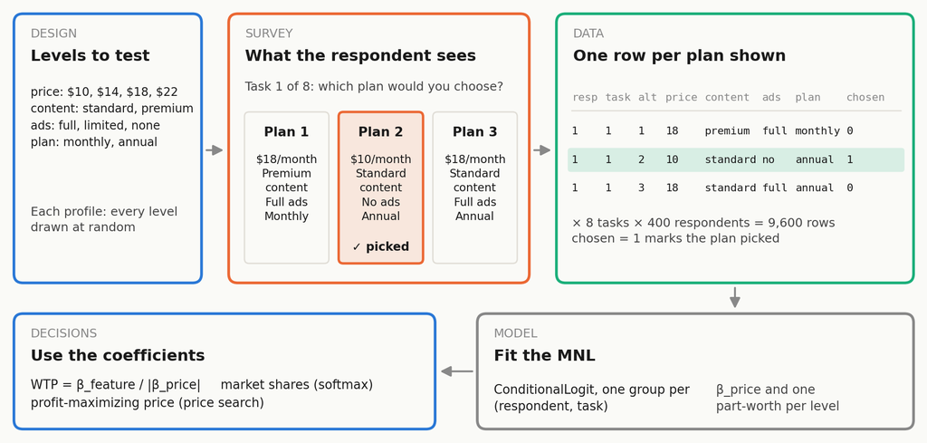

Respondent 1, task 1 of the HW09 dataset: one choice on the screen becomes three rows in the file.

## Multinomial Logit (MNL) Utility

You need this

Customer utility for option $j$:

$$U_j = \beta_{\text{price}} \cdot P_j + \beta_{\text{premium}} \cdot A_{\text{premium},j} + \beta_{\text{no_ads}} \cdot A_{\text{no_ads},j} + \varepsilon_j$$

**Parameters from fitted model:**

| Attribute | Coefficient |
| --- | --- |
| Price | $\beta_{\text{price}} = -0.15$ |
| Premium content | $\beta_{\text{premium}} = +1.10$ |
| No ads | $\beta_{\text{no_ads}} = +1.80$ |

$\beta_{\text{price}} < 0$ always (higher price = lower utility). If positive: sign error.

## Willingness to Pay

You need this

How many $ of price is this feature worth?

$$\text{WTP}_k = \frac{\beta_k}{|\beta_{\text{price}}|}$$

**Premium content:**

$$\text{WTP} = \frac{1.10}{0.15} = \mathbf{\$7.33}$$

**No ads:**

$$\text{WTP} = \frac{1.80}{0.15} = \mathbf{\$12.00}$$

Customers value no-ads $1.64\times$ more than premium content.

**Pricing implication:**  
An ad-free tier can command up to $12 more than the baseline.

## Softmax Market Simulation

You need this

Compute utility for each option, then market shares:

$$P(\text{choose } j) = \frac{e^{U_j}}{\sum_{k} e^{U_k}}$$

**Two products:**

$$U_X = -0.15 \times 10 = -1.5 \qquad U_Y = -0.15 \times 16 + 1.10 + 1.80 = 0.5$$

$$P(X) = \frac{e^{-1.5}}{e^{-1.5}+e^{0.5}} = \frac{0.223}{0.223+1.649} = \mathbf{11.9\%}$$

$$P(Y) = 1 - 0.119 = \mathbf{88.1\%}$$

## IIA: Independence of Irrelevant Alternatives

Adding a new option draws share from **all existing options proportionally** to their current shares.

**When it matters:**

Adding a product similar to Option X: IIA predicts equal proportional loss from X and Y.

**Reality:** similar products compete more with similar products.

**IIA fails when:**

New option is a close substitute for one existing option (Netflix adding a second drama tier).

Use Nested Logit instead.

## WTP is Not a Price Recommendation

**Warning**

**Conceptual distinction:** WTP is the mean of the willingness-to-pay distribution, not the revenue-maximizing price. Setting the price equal to mean WTP excludes all customers with below-average WTP and does not account for the price elasticity of demand at that level.

- WTP = $12 is the **average**. Customers with WTP < $12 won’t upgrade.
- Setting at $12 above base captures only customers with above-average WTP.
- Setting at $8 above base captures more customers at lower margin each.

**Optimal price:** the price that maximizes profit, $(p - c) \times s(p)$ (next slide). It need not sit below mean WTP.

## Profit-Maximizing Price

You need this

$$\text{profit per customer} = (p - c) \times s(p)$$

**Try many prices, keep the best.** Notes example: the firm sells B ($\beta_{\text{price}} = -0.18$, cost $c = \$6$); competitors keep A at $12 and C at $15. Recompute all three shares at each price:

| $p$ | $s(p)$ | $(p-6)\,s$ |
| --- | --- | --- |
| $15 | 81.3% | $7.32 |
| $18 | 71.7% | $8.61 |
| $21 | 59.7% | $8.95 |
| $24 | 46.3% | $8.33 |

Fine search: $p^* = \$20.52$, $s^* = 61.7\%$.

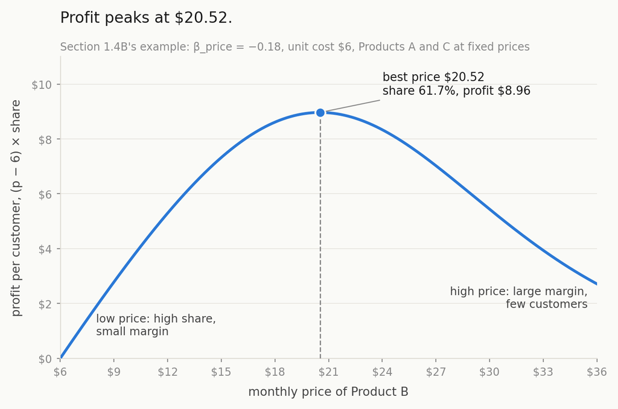

This is B’s best price at the competitors’ current prices; if one changes its price, search again. If the firm also sells A, maximize the profit of A and B together. Notes: Section 1.4D.

## Practice: work in pairs (1 of 2)

Answer each one, then mark **Sure** or **Unsure** as you would on the quiz.

**1. True or false?** Three plans have MNL shares of 20%, 30% and 50%. The firm cuts every plan’s price by $2. The MNL simulation still predicts 20% / 30% / 50%.

**2.** Plan A has a 60% share and Plan B has 40%. Plan C, a near-copy of B, launches and takes 20% of the market. What does MNL predict for A and B?

A. A 60%, B 20% B. A 48%, B 32% C. A 50%, B 30% D. A 40%, B 40%

**3.** With “no ads” as the reference level: $\beta_{\text{price}} = -0.15$, $\beta_{\text{full_ads}} = -2.00$, $\beta_{\text{limited_ads}} = -0.80$. What is the WTP to go from limited ads to no ads?

A. $13.33 B. $5.33 C. $8.00 D. $0.19

Answers in the lecture notes, under “Slide Practice Answers” (numbered to match these slides).

## Practice: work in pairs (2 of 2)

**4. True or false?** $\beta_{\text{premium}} = +1.20$ (vs standard content). So every respondent in the study prefers premium content to standard at the same price.

**5.** A direct survey asks “How much more would you pay for no ads?” and the average answer is $20. A conjoint study of the same customers puts WTP for no ads at $11. Which reading is right?

A. Trust $20: customers know their own preferences best  
B. Prefer $11, and still treat it as an upper bound to check against real purchases  
C. The gap shows the conjoint model is misspecified  
D. Average the two: $15.50

**6. True or false?** A market simulation gives Plan B a 55% share. The target market has 1,000,000 households, so Plan B will sign up about 550,000 of them.

Answers in the lecture notes, under “Slide Practice Answers” (numbered to match these slides).

## Checkpoint

1. $\beta_{\text{price}} = -0.18$, $\beta_{\text{annual_plan}} = +0.65$. Compute WTP for annual plan.
2. Two products with utilities $U_A = -1.5$ and $U_B = +0.5$. Compute market shares for both.
3. You add Option D (similar to B). Under IIA, which existing option loses the most share?
4. WTP for “no ads” = $10. Current base price = $8. Optimal premium tier price = $18? Defend or critique.
5. $\beta_{\text{price}} = +0.05$ from the MNL fit. What went wrong — and how do you fix it?

Answers in the lecture notes, under “Slide Checkpoint Answers” (numbered to match this slide).

## On your own data: conjoint for real

**Data:** one row per alternative shown, exactly one `chosen = 1` per task, and price varies within tasks.

**Tool:** `statsmodels` `ConditionalLogit`, with `groups` = one id per (respondent, task). A pooled binary Logit ignores the choice set.

**Prompt (excerpt):**

```
Fit a multinomial logit with statsmodels ConditionalLogit, groups = one id per
(respondent, task). Reference levels: <attribute: level>, ...
Market simulation: softmax shares among exactly these products: <...>
```

**Before you trust it:** $\beta_{\text{price}}$ is negative and significant · recompute one WTP and one share by hand · near-copies in the simulation mean an IIA warning · WTP from hypothetical choices is an upper bound.

**Don’t copy from HW09:** `seed=42`, products A/B/C, its reference levels. Those are pinned for grading.

Full card (data, tools, the complete prompt, all checks): [Agentic Prompts → L09](https://nu-mktg.github.io/marketing-analytics/md-viewer.html?file=student/agentic_prompts_14_models.md). Not quiz material.